# Order Tracking

Mohd Musharraf Parvez

2025-04-12

Name Mohd Musharraf Parvez reg_no 24221028 Under the guidance of Dr. Durgansh Sharma

1. Problem Statement / Objective This dataset appears to come from an order tracking/inventory system for event managemrnt. Based on this, we can define the following business problem:

Objective: To analyze the order processing workflow and identify patterns, delays, and performance metrics in shipping, assignment, and delivery to improve operational efficiency and customer satisfaction.

the following packages were incorporated for this project:

library(readxl)

📘 Purpose: To read Excel files (.xls and .xlsx) directly into R.

library(dplyr)

🧹 Purpose: To manipulate and transform data efficiently using verbs like filter, mutate, group_by, summarise, etc.

🔧 Used for:

Filtering data

Calculating summaries

Creating new columns like Shipping_Delay

library(ggplot2)

📊 Purpose: For creating data visualizations using a powerful and flexible grammar of graphics.

🔧 Used for:

Bar charts

Histograms

Pie charts (with tweaks)

Time series plots

library(lubridate)

🕒 Purpose: To work with dates and times easily and consistently.

🔧 Used for:

Parsing and formatting dates

Calculating time differences like Delivery_Days

library(tidyverse)

🌐 Purpose: This is a meta-package that includes ggplot2, dplyr, readr, tibble, tidyr, purrr, and stringr.

🔧 You don’t need both dplyr and tidyverse, since tidyverse already includes dplyr, ggplot2, and more.

library(scales)

🎚️ Purpose: To format axis labels and legends in ggplot2 plots (like percent, date formatting, currency).

🔧 Used for:

Customizing visual aesthetics

Scaling values in plots

# Plot: Current Status

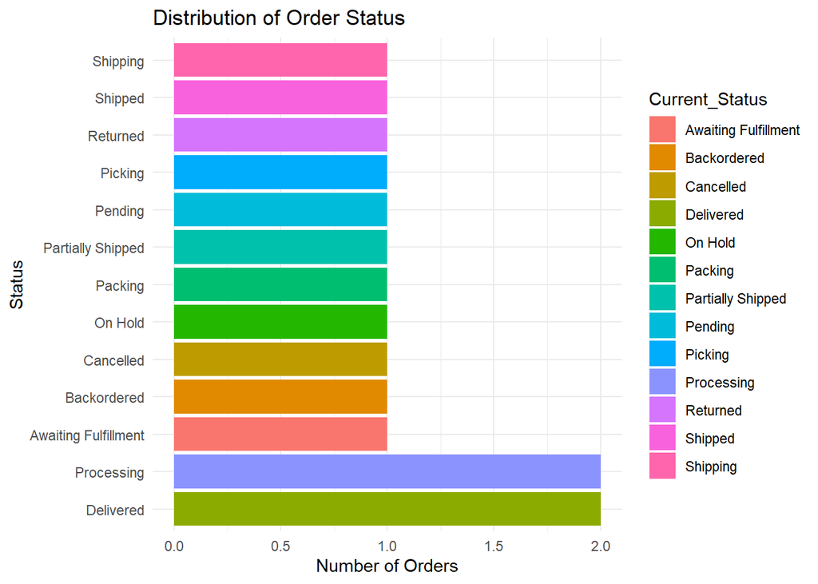

This bar chart titled “Distribution of Order Status” gives a visual summary of how customer orders are currently progressing through different stages of the order fulfillment pipeline.

📊 What the Graph Shows: The x-axis represents the number of orders for each status.

The y-axis lists the various order statuses such as:

Pending, Processing, Shipped, Delivered, etc.

Each bar’s length indicates how many orders fall into that status.

The bars are color-coded by Current_Status for visual clarity (legend shown on the right).

🔎 Key Observations: ✅ Most Frequent Statuses:

Processing and Delivered each have 2 orders, indicating that:

Some orders are actively being worked on (Processing)

Some have completed the cycle (Delivered)

🟨 Other Statuses (1 Order Each):

Every other status (e.g., Cancelled, Packing, Pending, etc.) has exactly 1 order.

This shows a very even spread across different workflow stages, which may indicate:

A variety of order types being handled simultaneously

Small dataset (15 records), so small differences are visually significant

⚠️ Cancelled, Backordered, On Hold

These are potential bottlenecks or issues in the order cycle and might need attention if they grow in frequency.

🧠 Business Insight: The system seems to be managing diverse order statuses, but:

There is no clear majority status, suggesting a scattered workflow.

If this is a real-world scenario, more orders should ideally move toward Delivered or Shipped.

# Cancellation Reasons

No single issue is dominant yet—but all three are critical to monitor in case of future spikes.

# Plot: Cancellation Reasons

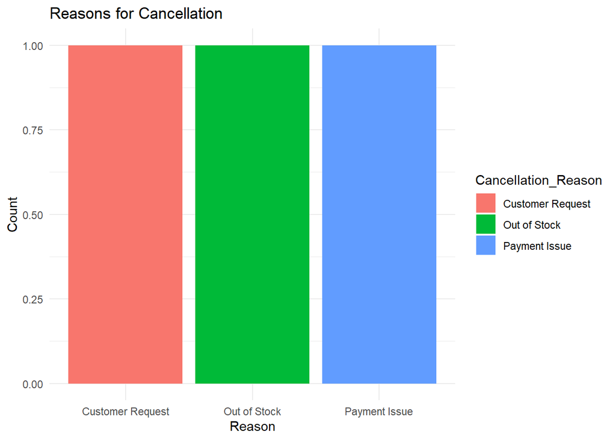

# Plot:order Stat

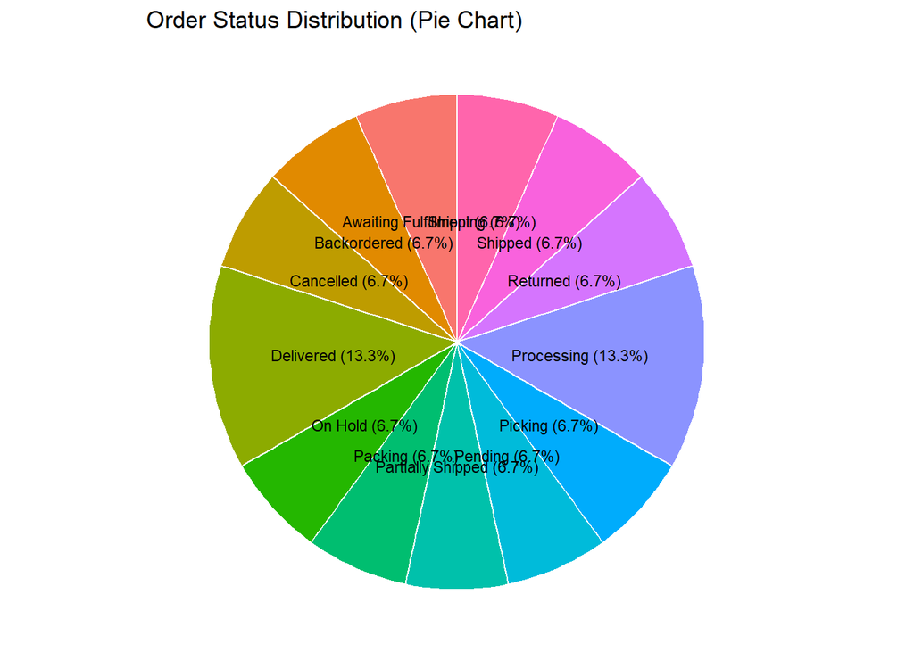

Each slice represents a status and the percentage of total orders it accounts for.

🔍 Key Insights: Status Percentage Interpretation Delivered 13.3% A good sign — orders are being completed Processing 13.3% Indicates ongoing work on some orders All Others 6.7% each Remaining orders are distributed across stages: Pending, Packing, Cancelled, On Hold, Returned, etc. 🧠 Business Insight: The top 2 statuses (Processing + Delivered) show the most activity — suggesting efficient flow.

The rest are evenly distributed, possibly due to:

A small dataset

Or a wide variety of order scenarios (like backorders, returns, fulfillment delays)